# US-Anleihenmarkt auf der Blockchain: Oktober 2023 Marktübersicht

Der Anleihenmarkt ist nicht nur der weltweit größte Finanzmarkt, sondern auch von entscheidender Bedeutung für die Finanzierung von Staaten und Unternehmen. Insbesondere in Anbetracht der jüngsten Zinserhöhungen der Federal Reserve (FED) gewinnt dieser Markt erneut an Attraktivität für Anleger, die zuvor vor allem im Aktienmarkt nach Renditen suchten.

Mit der Entstehung von Bitcoin kam die aufregende Technologie der Blockchain zur Welt. Obwohl sie vielversprechend ist, wurden bisher nur wenige bedeutende Projekte und Produkte entwickelt, die auf dieser Technologie basieren – abseits der Spekulation im Kryptowährungsmarkt. Real-World-Assets sind genau das, was der Name bereits verrät: reale Vermögenswerte, die auf einer Blockchain verwaltet werden. Dazu gehören beispielsweise Anleihen, Kredite und staatliche Währungen (Stablecoins).

Das Hauptziel dieses Projekts besteht darin, den US-Anleihenmarkt auf der Blockchain zu analysieren. Dabei werden sowohl SQL-Abfragen als auch das Datenvisualisierungs-Tool Metabase eingesetzt. Mit diesen Werkzeugen werde ich ein Dashboard erstellen, das Einblicke in den Markt für US-Anleihen bietet. Meine Daten stammen von der Website rwa.xyz, die eine maßgebliche Quelle für tokenisierte reale Vermögenswerte darstellt. Ich werde die führenden Wettbewerber identifizieren, die am häufigsten verwendeten Blockchain-Plattformen für die Verwaltung von Anleihen ermitteln und die damit verbundenen Gebühren untersuchen.

### Einrichtung der Datenbank und Datenerfassung

Im ersten Schritt habe ich eine Datenbank namens ‘rwa’ erstellt und die Tabelle ‘treasuries’ konfiguriert. Anschließend habe ich die Daten aus einer CSV-Datei in diese Tabelle geladen. Dies bildet die Grundlage für meine Analyse.

```sql
-- Datenbank namens 'rwa' erstellen
CREATE DATABASE rwa;

-- Tabelle 'treasuries' erstellen
CREATE TABLE treasuries (
    Protocol text,
    Network text,
    Manager_Name text,
    Ticker text,
    Name text,
    Market_Cap numeric(16,2),
    Yield_to_Maturity numeric(6,2),
    Weighted_Average_Maturity numeric(6,2),
    Total_Management_Fee numeric(6,2),
    Min_Initial_Deposit numeric(11,2),
    Min_Subsequent_Deposit numeric(11,2),
    Primary_Currency char(5),
    Contract_Address text,
    Redemption_Description text,
    Contract_Type text,
    Decimals numeric(6,2),
    Subscription_Fee numeric(6,2),
    Redemption_Fee numeric(6,2),
    Subscription_Description text,
    Token_Supply numeric(16,2),
    Product_Description text,
    Custodian_Name text,
    Jurisdiction text,
    Investor_Protections_Description text,
    KYC_Required boolean,
    Investors_Allowed_Description text,
    Transferability_Description text,
    Fee_Description text,
    Other_Fees_Description text
);

-- CSV-Daten in PostgreSQL laden
COPY treasuries
FROM '/Users/my_personal_path/treasuries.csv'
WITH (FORMAT CSV, HEADER);

-- Überprüfen, ob die Daten richtig übernommen wurden
TABLE treasuries;
```

## SQL-Analyse

Im zweiten Schritt habe ich gezielte SQL-Abfragen erstellt, um wichtige Fragestellungen zu klären. Diese SQL-Abfragen bilden die Basis für die Visualisierungen in Metabase.

```sql
-- Marktkapitalisierung nach Netzwerk
SELECT network, SUM(market_cap) as total_market_cap
FROM treasuries
GROUP BY network
ORDER BY network ASC;

-- Vermögensverwalter nach AUM
SELECT protocol, SUM(market_cap) AS market_cap_sum
FROM treasuries
WHERE market_cap > 0
GROUP BY protocol
ORDER BY market_cap_sum DESC;

-- Durchschnittliche Umlaufrendite
SELECT ROUND(AVG(yield_to_maturity),2) AS average_yield
FROM treasuries;

-- Durchschnittliche Gebühr
SELECT ROUND(AVG(total_management_fee), 2) AS average_fee
FROM treasuries;

-- Gesamte Marktkapitalisierung
SELECT SUM(market_cap) AS total_market_cap
FROM treasuries;
```

### SQL: Zeitreihenanalyse

Die Website rwa.xyz hat für Zeitreihen-Daten eine eigene CSV-Datei. Deshalb habe ich zuerst eine Taballe in meiner PostgreSQL-Datenbank erstellt und anschließend die Daten geladen. Da das Datum in einer nicht optimalen Form vorlag, war es notwendig, es in ein passendes Zeitstempel-Format zu konvertieren, um eine korrekte Datenanalyse durchzuführen.

```sql
-- Tabelle 'treasuries_ts' erstellen
CREATE TABLE treasuries_ts (
    timestamp bigint,
    protocol TEXT NOT NULL,
    market_cap numeric(20, 8),
    date TEXT
);

-- CSV_Datei in PostgreSQL laden
COPY treasuries_ts
FROM '/Users/my_personal_path/treasury-timeseries.csv'
WITH (FORMAT CSV, HEADER);

-- Überprüfen, ob die Daten richtig übernommen wurden
TABLE treasuries_ts;

-- Spalte fürs Datum hinzufügen
ALTER TABLE treasuries_ts ADD COLUMN date_as_timestamp TIMESTAMP;

-- convert 'date' string to timestamp format and store in 'date_as_timestamp'
UPDATE treasuries_ts
SET date_as_timestamp = to_timestamp(
    substring(date from 5 for 20),
    'Mon DD YYYY HH24:MI:SS'
);

-- Spalte 'date' wieder löschen
ALTER TABLE treasuries_ts DROP COLUMN date;

-- Spalte umbenennen
ALTER TABLE treasuries_ts RENAME COLUMN date_as_timestamp TO date;

-- Überprüfen, ob alles geklappt hat
TABLE treasuries_ts;

-- Zeitreihe erstellen nach Vermögensverwalter sortiert
SELECT protocol, market_cap, date
FROM treasuries_ts
GROUP BY protocol, market_cap, date
ORDER BY protocol ASC, date ASC;
```

### Datenvisualisierung mit Metabase

Meine Wahl fiel auf Metabase, da es mehrere Vorteile bietet. Es unterstützt SQL-Abfragen, ist eine Open-Source-Plattform und kostenlos nutzbar. Außerdem überzeugt Metabase durch seine nahtlose Integration mit meiner PostgreSQL-Datenbank. Die Benutzerfreundlichkeit von Metabase ermöglicht es, mühelos verständliche Visualisierungen zu erstellen.

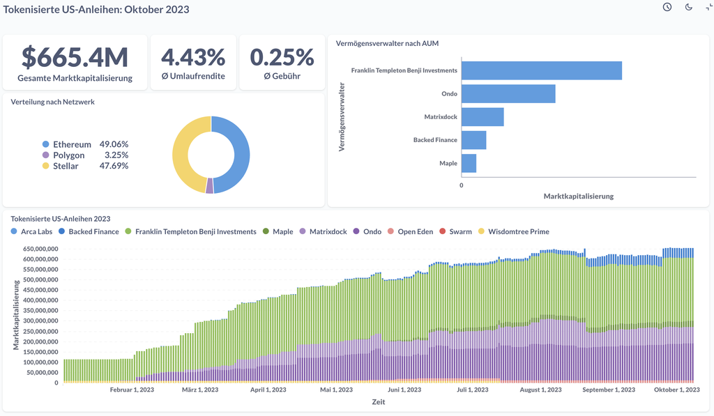

Die in diesem Projekt verwendeten Daten stammen von der Webseite rwa.xyz, insbesondere von den Seiten Treasuries und Downloads. Diese Quellen dienten als Grundlage für die Analyse des US-Anleihenmarkts auf der Blockchain und die Erstellung der visualisierten Ergebnisse.

### Zusammenfassung der Ergebnisse

Die Ergebnisse der Analyse des US-Anleihenmarkts auf der Blockchain im Oktober 2023 zeigten, dass die Gebühren auf einem günstigen Niveau liegen, vergleichbar mit ETF-Gebühren. Die Gesamtmarktkapitalisierung mit 665,4 Millionen USD ist im Vergleich zum gesamten Anleihenmarkt relativ niedrig. Dies ist jedoch vor dem Hintergrund zu betrachten, dass der Markt für tokenisierte Anleihen erst in den letzten Jahren rasant gewachsen ist.

Die Ergebnisse dieser Analyse deuten darauf hin, dass der Markt für tokenisierte Anleihen auf der Blockchain beträchtliches Wachstumspotenzial aufweist. Insbesondere wenn etablierte Vermögensverwalter ihr Angebot auf blockchainbasierte Anleihen ausweiten, könnte der Markt erheblich an Größe gewinnen. Dies könnte die Art und Weise, wie Finanzanlagen verwaltet und gehandelt werden, grundlegend verändern. Es ist nicht unrealistisch anzunehmen, dass in Zukunft eine breite Palette von Finanzanlagen tokenisiert wird, was möglicherweise zu einer umfassenden Demokratisierung des Finanzwesens führt.